# Análisis de variables climáticas seleccionadas (España, por provincia)

2026-10-08

Análisis y validación, como dataset para el proyecto personal de **AEDV**, de las variables climáticas de **España por provincia**, generadas en CLIMA_SPAIN_TableDatasetGeneration.Rmd. Los **datasets a evaluar son las variables climáticas**: cada variable es un atributo medido por provincia y mes. La fuente es el **histórico observado** `observaciones_spain.rds`. También se analiza `proyecciones_spain.rds` y se incluyen **mapas coropléticos**.

Igual que el resto de documentos de selección de datasets de la asignatura, este tiene **dos partes independientes**:

1. **Selección de variables y guardado de metadatos** — elige las variables a analizar y deja en disco su ficha (`CLIMA_SPAIN_metadatos.xlsx`). Los datos en sí (los dos `.rds`) los genera `CLIMA_SPAIN_TableDatasetGeneration.Rmd`, que es el que descarga los NetCDF de AdapteCCa.
2. **Análisis del dataset** — parte de esos ficheros del disco y no usa nada de la sección anterior, de modo que **se puede copiar tal cual en la memoria del proyecto**.

```r
# nombre base de los ficheros de metadatos y ficheros de datos ya generados
filename <- "CLIMA_SPAIN"
f_obs    <- "observaciones_spain.rds"
f_proy   <- "proyecciones_spain.rds"
```

# 1 Selección de variables y guardado de metadatos

Las variables a analizar se seleccionan por su código (`variable`):

```r
VARS <- c("tasmax", "tasmin", "tmean", "tasmaxmax", "tasminmin",
          "tasminNa20", "tasminNb0", "tasmaxNap90", "tasminNap90",
          "tasmaxhwdmax", "pr", "prNa1", "prmax24", "prmax5days")
```

A diferencia del INE, el ISTAC, EUROSTAT o el Banco Mundial, AdapteCCa **no tiene un catálogo previo** del que extraer la ficha del dataset: aquí los metadatos se construyen en este mismo documento y se guardan en `CLIMA_SPAIN_metadatos.xlsx`, con **cuatro hojas**:

- `dataset` — la ficha general (fuente, rejillas, cobertura, tamaño de los dos ficheros).
- `variables` — el significado de cada variable climática, con su categoría y su unidad.
- `horizontes` — el periodo de 30 años que representa cada horizonte de las proyecciones.
- `escenarios` — las 4 trayectorias de emisión SSP, con su forzamiento y su calentamiento estimado.

Las tres últimas son las **explicaciones de los indicadores**, que es lo que en las otras fuentes viene ya dado en el catálogo (`Indicator_desc` en el Banco Mundial, `Descripcion` del `topic` en EUROSTAT).

> **Nota:** las descripciones han sido redactadas a partir de la documentación de AdapteCCa (variables/índices del visor) y del 6º Informe del IPCC. **No provienen literalmente de la API.** Si se cambian las variables seleccionadas, habrá que revisar/ampliar las descripciones.

```r
# DESCRIPCIÓN DE CADA VARIABLE CLIMÁTICA (columna `variable` de los dos rds)
desc_var <- tibble::tribble(
  ~variable,       ~categoria,       ~description,
  "tasmax",        "Temperatura",    "Media mensual de la temperatura máxima diaria a 2 m.",
  "tasmin",        "Temperatura",    "Media mensual de la temperatura mínima diaria a 2 m.",
  "tmean",         "Temperatura",    "Media mensual de la temperatura media diaria a 2 m.",
  "tasmaxmax",     "Temperatura",    "Máximo mensual de la temperatura máxima diaria (extremo cálido del mes).",
  "tasminmin",     "Temperatura",    "Mínimo mensual de la temperatura mínima diaria (extremo frío del mes).",
  "tasminNa20",    "Temperatura",    "Nº de días al mes con temperatura mínima > 20 °C (noches tropicales).",
  "tasminNb0",     "Temperatura",    "Nº de días al mes con temperatura mínima < 0 °C (días de helada).",
  "tasmaxNap90",   "Temperatura",    "Nº de días al mes con temperatura máxima por encima del percentil 90 (días cálidos).",
  "tasminNap90",   "Temperatura",    "Nº de días al mes con temperatura mínima por encima del percentil 90 (noches cálidas).",
  "tasmaxhwdmax",  "Temperatura",    "Duración máxima de ola de calor: días consecutivos con Tmáx > percentil 90.",
  "pr",            "Precipitación",  "Media mensual de la precipitación diaria acumulada.",
  "prNa1",         "Precipitación",  "Nº de días al mes con precipitación > 1 mm (días de lluvia).",
  "prmax24",       "Precipitación",  "Máxima precipitación mensual acumulada en 1 día (RX1day).",
  "prmax5days",    "Precipitación",  "Máxima precipitación mensual acumulada en 5 días (RX5day)."
)
```

```r
# PERIODO DE 30 AÑOS QUE REPRESENTA CADA HORIZONTE (AdapteCCa / Escenarios-PNACC)
desc_horizonte <- tibble::tribble(
  ~horizonte,      ~periodo,     ~denominacion,
  "reference",     "1971-2000",  "base histórica",
  "near_future",   "2011-2040",  "futuro cercano",
  "medium_future", "2041-2070",  "futuro medio",
  "far_future",    "2071-2100",  "futuro lejano"
)
```

```r
# LAS 4 TRAYECTORIAS DE EMISIÓN SSP (CMIP6 / IPCC-AR6).
# Nombres de columna sin espacios ni tildes para que sobrevivan al viaje por el
# xlsx; las etiquetas legibles se ponen al imprimir la tabla, más abajo.
desc_escenario <- tibble::tribble(
  ~escenario, ~SSP,       ~relato,                              ~forzamiento_2100, ~emisiones,  ~calentamiento_2100_AR6, ~description,
  "ssp126",   "SSP1-2.6", "Sostenibilidad",                     "~2,6 W/m²",       "Bajas",     "~1,8 °C (1,3–2,4)",     "CO₂ neto cero hacia ~2050. Compatible con limitar el calentamiento bien por debajo de 2 °C (Acuerdo de París).",
  "ssp245",   "SSP2-4.5", "Camino intermedio",                  "~4,5 W/m²",       "Medias",    "~2,7 °C (2,1–3,5)",     "Emisiones intermedias; políticas climáticas a ritmo moderado. Escenario 'central' de referencia.",
  "ssp370",   "SSP3-7.0", "Rivalidad regional",                 "~7,0 W/m²",       "Altas",     "~3,6 °C (2,8–4,6)",     "Mundo fragmentado, poca cooperación; las emisiones casi se duplican hacia 2100.",
  "ssp585",   "SSP5-8.5", "Desarrollo por combustibles fósiles","~8,5 W/m²",       "Muy altas", "~4,4 °C (3,3–5,7)",     "Crecimiento intensivo en fósiles. Límite superior plausible de emisiones."
)
```

La ficha general y la unidad de cada variable se calculan a partir de los `.rds` ya guardados en disco, para que describan exactamente lo que hay en ellos y no lo que se esperaba generar.

```r
hist_all <- readRDS(f_obs) |> as_tibble()
proy_all <- readRDS(f_proy) |> as_tibble()

# la unidad no se escribe a mano: se lee de los propios datos
unidades <- hist_all |> distinct(variable, unidad)

variables_sel <- desc_var |>
  filter(variable %in% VARS) |>
  left_join(unidades, by = "variable") |>
  mutate(area = "PROV", frecuencia = "Mensual") |>
  relocate(unidad, area, frecuencia, .after = categoria)

ficha <- tibble(
  Campo = c("Fuente", "Coleccion", "Ambito", "Rejillas", "Metodos.downscaling", "URL",
            "Fecha.de.generacion",
            "Fichero.observaciones", "Obs.N.filas", "Obs.N.variables",
            "Obs.N.provincias", "Obs.Freq", "Obs.Ini", "Obs.Fin", "Obs.N.periodos",
            "Fichero.proyecciones", "Proy.N.filas", "Proy.N.escenarios",
            "Proy.N.modelos", "Proy.N.horizontes", "Proy.N.meses"),
  Valor = c(
    "Visor AdapteCCa (OECC/MITECO, AEMET, CSIC y Fundación Biodiversidad)",
    "Escenarios-PNACC 2024",
    "España, provincias",
    paste("ROCIO_IBEB (~5 km) para Península, Baleares, Ceuta y Melilla;",
          "ROCIO+_CAN (~2,5 km) para Canarias"),
    "ESD-RegBA (temperatura) y deepESD (precipitación)",
    "https://escenarios.adaptecca.es/",
    as.character(Sys.Date()),
    f_obs,
    as.character(nrow(hist_all)),
    as.character(n_distinct(hist_all$variable)),
    as.character(n_distinct(hist_all$cpro)),
    "M (mensual)",
    as.character(min(hist_all$fecha)),
    as.character(max(hist_all$fecha)),
    as.character(n_distinct(hist_all$fecha)),
    f_proy,
    as.character(nrow(proy_all)),
    as.character(n_distinct(proy_all$escenario)),
    as.character(n_distinct(proy_all$modelo)),
    as.character(n_distinct(proy_all$horizonte)),
    as.character(n_distinct(proy_all$mes))
  )
)

# comprobación: toda variable seleccionada tiene que existir en los datos y tener
# descripción, y todo horizonte/escenario de las proyecciones estar documentado
faltan_desc <- setdiff(VARS, desc_var$variable)
faltan_dato <- setdiff(VARS, unique(hist_all$variable))
faltan_hor  <- setdiff(unique(proy_all$horizonte), desc_horizonte$horizonte)
faltan_esc  <- setdiff(unique(proy_all$escenario), desc_escenario$escenario)
if(length(faltan_desc) > 0) warning("Variables sin descripción: ", paste(faltan_desc, collapse = ", "))
if(length(faltan_dato) > 0) warning("Variables que no están en el rds: ", paste(faltan_dato, collapse = ", "))
if(length(faltan_hor)  > 0) warning("Horizontes sin descripción: ", paste(faltan_hor, collapse = ", "))
if(length(faltan_esc)  > 0) warning("Escenarios sin descripción: ", paste(faltan_esc, collapse = ", "))

# las cuatro hojas en un solo xlsx: openxlsx toma el nombre de cada hoja del
# nombre del elemento de la lista
write.xlsx(list(dataset    = ficha,
                variables  = variables_sel,
                horizontes = desc_horizonte,
                escenarios = desc_escenario),
           file = paste0(filename, "_metadatos.xlsx"), overwrite = TRUE)

cat("Fichero guardado:", paste0(filename, "_metadatos.xlsx"),
    "- hojas: dataset, variables, horizontes, escenarios\n")
```

```
## Fichero guardado: CLIMA_SPAIN_metadatos.xlsx - hojas: dataset, variables, horizontes, escenarios
```

```r
cat("Variables seleccionadas:", nrow(variables_sel), "de", length(VARS), "\n")
```

```
## Variables seleccionadas: 14 de 14
```

```r
cat("Elementos sin descripción:", length(faltan_desc), "variables,",
    length(faltan_hor), "horizontes,", length(faltan_esc), "escenarios\n")
```

```
## Elementos sin descripción: 0 variables, 0 horizontes, 0 escenarios
```

Una vez guardados en disco los metadatos (fichero xlsx) y estando ya los datos (los dos ficheros RDS), iniciamos el proceso de análisis. A partir de aquí el documento se compila **solo** con los ficheros ya guardados en disco; no se usa ningún objeto de la sección anterior. Es a propósito: es la parte que se incorpora a la memoria del proyecto personal (ver la última sección, *Incorporación del dataset a la memoria*), así que tiene que poder ejecutarse sola (lo único que se repite de lo definido antes son los nombres de fichero).

# 2 Análisis del dataset

**metadatos**

| Campo | Valor |
| --- | --- |
| Fuente | Visor AdapteCCa (OECC/MITECO, AEMET, CSIC y Fundación Biodiversidad) |
| Coleccion | Escenarios-PNACC 2024 |
| Ambito | España, provincias |
| Rejillas | ROCIO_IBEB (~5 km) para Península, Baleares, Ceuta y Melilla; ROCIO+_CAN (~2,5 km) para Canarias |
| Metodos.downscaling | ESD-RegBA (temperatura) y deepESD (precipitación) |
| URL | https://escenarios.adaptecca.es/ |
| Fecha.de.generacion | 2026-10-08 |
| Fichero.observaciones | observaciones_spain.rds |
| Obs.N.filas | 603192 |
| Obs.N.variables | 14 |
| Obs.N.provincias | 52 |
| Obs.Freq | M (mensual) |
| Obs.Ini | 1951-01 |
| Obs.Fin | 2022-12 |
| Obs.N.periodos | 864 |
| Fichero.proyecciones | proyecciones_spain.rds |
| Proy.N.filas | 1677312 |
| Proy.N.escenarios | 4 |
| Proy.N.modelos | 12 |
| Proy.N.horizontes | 4 |
| Proy.N.meses | 12 |

## 2.1 Origen de los datos: AdapteCCa

Todos los datos provienen del **Visor de Escenarios de Cambio Climático de AdapteCCa**, la plataforma oficial sobre adaptación al cambio climático en España (colección **Escenarios-PNACC**: OECC/MITECO, AEMET, CSIC y Fundación Biodiversidad; desarrollo IFCA-UC y Predictia). Se distribuyen en NetCDF vía **THREDDS**.

España se cubre con **dos rejillas observacionales de AEMET** que aquí se combinan por provincia:

- **ROCIO_IBEB (~5 km)** → Península, Baleares, Ceuta y Melilla.
- **ROCIO+_CAN (~2,5 km)** → Canarias.

Cada provincia toma su valor de la rejilla que la cubre. Hay dos productos:

### 2.1.1 Observaciones: el clima registrado

Clima **realmente medido**: observaciones diarias de las estaciones de AEMET, interpoladas a rejilla y agregadas a valores mensuales (medias, conteos de días, máximos…). La cobertura temporal difiere por dominio: **Península/Baleares 1951–2022** (2022 incompleto) y **Canarias 1990–2022**. Es la **línea base** real.

### 2.1.2 Proyecciones: el clima simulado (siglo XXI)

Clima **simulado**: se parte de los modelos globales **CMIP6** (IPCC-AR6, ~100 km) y se **regionaliza (downscaling) estadísticamente** con *machine learning* a la rejilla de AEMET, con dos métodos según la variable: **ESD-RegBA** (AEMET, temperatura) y **deepESD** (CSIC, precipitación). El resultado son **climatologías** (medias de 30 años) para los **4 escenarios SSP** × **4 horizontes**: la base histórica de referencia (1971–2000) y 3 horizontes futuros (2011–2040, 2041–2070, 2071–2100). Detalle de escenarios al final.

## 2.2 Variables (datasets) seleccionadas

| variable | categoría | unidad | área | frecuencia | descripción |
| --- | --- | --- | --- | --- | --- |
| tasmax | Temperatura | °C | PROV | Mensual | Media mensual de la temperatura máxima diaria a 2 m. |
| tasmin | Temperatura | °C | PROV | Mensual | Media mensual de la temperatura mínima diaria a 2 m. |
| tmean | Temperatura | °C | PROV | Mensual | Media mensual de la temperatura media diaria a 2 m. |
| tasmaxmax | Temperatura | °C | PROV | Mensual | Máximo mensual de la temperatura máxima diaria (extremo cálido del mes). |
| tasminmin | Temperatura | °C | PROV | Mensual | Mínimo mensual de la temperatura mínima diaria (extremo frío del mes). |
| tasminNa20 | Temperatura | días | PROV | Mensual | Nº de días al mes con temperatura mínima > 20 °C (noches tropicales). |
| tasminNb0 | Temperatura | días | PROV | Mensual | Nº de días al mes con temperatura mínima < 0 °C (días de helada). |
| tasmaxNap90 | Temperatura | días | PROV | Mensual | Nº de días al mes con temperatura máxima por encima del percentil 90 (días cálidos). |
| tasminNap90 | Temperatura | días | PROV | Mensual | Nº de días al mes con temperatura mínima por encima del percentil 90 (noches cálidas). |
| tasmaxhwdmax | Temperatura | días | PROV | Mensual | Duración máxima de ola de calor: días consecutivos con Tmáx > percentil 90. |
| pr | Precipitación | mm | PROV | Mensual | Media mensual de la precipitación diaria acumulada. |
| prNa1 | Precipitación | días | PROV | Mensual | Nº de días al mes con precipitación > 1 mm (días de lluvia). |
| prmax24 | Precipitación | mm | PROV | Mensual | Máxima precipitación mensual acumulada en 1 día (RX1day). |
| prmax5days | Precipitación | mm | PROV | Mensual | Máxima precipitación mensual acumulada en 5 días (RX5day). |

## 2.3 Datos: serie histórica observada

**data**

```
## # A tibble: 603,192 × 6
##   VARIABLE REGION   CPRO  UNIDAD TIME    VALUE
##   <chr>    <chr>    <chr> <chr>  <chr>   <dbl>
## 1 pr       Albacete 02    mm     1952-01  0.81
## 2 pr       Albacete 02    mm     1952-02  0.46
## 3 pr       Albacete 02    mm     1952-03  1.25
## 4 pr       Albacete 02    mm     1952-04  2.83
## 5 pr       Albacete 02    mm     1952-05  1.43
## # ℹ 603,187 more rows
```

Muestra de las primeras 20 filas del histórico observado por provincia, variable y mes:

| VARIABLE | REGION | CPRO | UNIDAD | TIME | VALUE |
| --- | --- | --- | --- | --- | --- |
| pr | Albacete | 02 | mm | 1952-01 | 0.81 |
| pr | Albacete | 02 | mm | 1952-02 | 0.46 |
| pr | Albacete | 02 | mm | 1952-03 | 1.25 |
| pr | Albacete | 02 | mm | 1952-04 | 2.83 |
| pr | Albacete | 02 | mm | 1952-05 | 1.43 |
| pr | Albacete | 02 | mm | 1952-06 | 0.45 |
| pr | Albacete | 02 | mm | 1952-07 | 1.21 |
| pr | Albacete | 02 | mm | 1952-08 | 1.56 |
| pr | Albacete | 02 | mm | 1952-09 | 0.97 |
| pr | Albacete | 02 | mm | 1952-10 | 0.52 |
| pr | Albacete | 02 | mm | 1952-11 | 0.48 |
| pr | Albacete | 02 | mm | 1952-12 | 1.57 |
| pr | Albacete | 02 | mm | 1953-01 | 0.19 |
| pr | Albacete | 02 | mm | 1953-02 | 0.43 |
| pr | Albacete | 02 | mm | 1953-03 | 0.73 |
| pr | Albacete | 02 | mm | 1953-04 | 1.70 |
| pr | Albacete | 02 | mm | 1953-05 | 0.11 |
| pr | Albacete | 02 | mm | 1953-06 | 1.17 |
| pr | Albacete | 02 | mm | 1953-07 | 0.73 |
| pr | Albacete | 02 | mm | 1953-08 | 0.23 |

## 2.4 Análisis de series temporales por variable

> Criterio de rango temporal: **P25** ≥ umbral según frecuencia (**≥ 10** anual, **≥ 40** trimestral, **≥ 60** mensual). P25 es el tamaño de serie que supera el 75 % de las provincias.

**Por variable**: nº de provincias, rango de fechas y percentiles del tamaño de serie temporal (periodos por provincia).

| VARIABLE | categoria | freq_obs | n_regiones | date_start | date_end | P0 | P25 | P50 | P75 | P100 |
| --- | --- | --- | --- | --- | --- | --- | --- | --- | --- | --- |
| pr | Precipitación | M | 52 | 1952-01 | 2022-12 | 396 | 852 | 852 | 852 | 852 |
| prNa1 | Precipitación | M | 52 | 1951-01 | 2022-12 | 396 | 864 | 864 | 864 | 864 |
| prmax24 | Precipitación | M | 52 | 1952-01 | 2022-12 | 396 | 852 | 852 | 852 | 852 |
| prmax5days | Precipitación | M | 52 | 1952-01 | 2022-12 | 396 | 852 | 852 | 852 | 852 |
| tasmax | Temperatura | M | 52 | 1951-01 | 2022-12 | 396 | 858 | 858 | 858 | 858 |
| tasmaxNap90 | Temperatura | M | 52 | 1951-01 | 2022-12 | 396 | 864 | 864 | 864 | 864 |
| tasmaxhwdmax | Temperatura | M | 52 | 1951-01 | 2022-12 | 396 | 660 | 660 | 660 | 660 |
| tasmaxmax | Temperatura | M | 52 | 1951-01 | 2022-12 | 396 | 864 | 864 | 864 | 864 |
| tasmin | Temperatura | M | 52 | 1951-01 | 2022-12 | 396 | 864 | 864 | 864 | 864 |
| tasminNa20 | Temperatura | M | 52 | 1951-01 | 2022-12 | 396 | 864 | 864 | 864 | 864 |
| tasminNap90 | Temperatura | M | 52 | 1951-01 | 2022-12 | 396 | 864 | 864 | 864 | 864 |
| tasminNb0 | Temperatura | M | 52 | 1951-01 | 2022-12 | 396 | 864 | 864 | 864 | 864 |
| tasminmin | Temperatura | M | 52 | 1951-01 | 2022-12 | 396 | 864 | 864 | 864 | 864 |
| tmean | Temperatura | M | 52 | 1951-01 | 2022-12 | 396 | 858 | 858 | 858 | 858 |

## 2.5 Provincias y número de observaciones

| CPRO | REGION | n_obs |
| --- | --- | --- |
| 02 | Albacete | 11844 |
| 03 | Alicante/Alacant | 11844 |
| 04 | Almería | 11844 |
| 01 | Araba/Álava | 11844 |
| 33 | Asturias | 11844 |
| 06 | Badajoz | 11844 |
| 07 | Balears, Illes | 11844 |
| 08 | Barcelona | 11844 |
| 48 | Bizkaia | 11844 |
| 09 | Burgos | 11844 |
| 39 | Cantabria | 11844 |
| 12 | Castellón/Castelló | 11844 |
| 51 | Ceuta | 11796 |
| 13 | Ciudad Real | 11844 |
| 15 | Coruña, A | 11844 |
| 16 | Cuenca | 11844 |
| 10 | Cáceres | 11844 |
| 11 | Cádiz | 11844 |
| 14 | Córdoba | 11844 |
| 20 | Gipuzkoa | 11844 |
| 17 | Girona | 11844 |
| 18 | Granada | 11844 |
| 19 | Guadalajara | 11844 |
| 21 | Huelva | 11844 |
| 22 | Huesca | 11844 |
| 23 | Jaén | 11844 |
| 24 | León | 11844 |
| 25 | Lleida | 11844 |
| 27 | Lugo | 11844 |
| 28 | Madrid | 11844 |
| 52 | Melilla | 11796 |
| 30 | Murcia | 11844 |
| 29 | Málaga | 11844 |
| 31 | Navarra | 11844 |
| 32 | Ourense | 11844 |
| 34 | Palencia | 11844 |
| 35 | Palmas, Las | 5544 |
| 36 | Pontevedra | 11844 |
| 26 | Rioja, La | 11844 |
| 37 | Salamanca | 11844 |
| 38 | Santa Cruz de Tenerife | 5544 |
| 40 | Segovia | 11844 |
| 41 | Sevilla | 11844 |
| 42 | Soria | 11844 |
| 43 | Tarragona | 11844 |
| 44 | Teruel | 11844 |
| 45 | Toledo | 11844 |
| 46 | Valencia/València | 11844 |
| 47 | Valladolid | 11844 |
| 49 | Zamora | 11844 |
| 50 | Zaragoza | 11844 |
| 05 | Ávila | 11844 |

## 2.6 Validación de requisitos AEDV

**Validación de requisitos AEDV** — umbrales: > 40 provincias, último dato ≥ 2024, P25 ≥ 60 meses.

| Variable | Cobertura geográfica | Datos actualizados (≥ 2024) | Tamaño series (P25 ≥ umbral) | CUMPLE LOS 3 |
| --- | --- | --- | --- | --- |
| pr [M] | ✔ | ✘ | ✔ | ✘ |
| prNa1 [M] | ✔ | ✘ | ✔ | ✘ |
| prmax24 [M] | ✔ | ✘ | ✔ | ✘ |
| prmax5days [M] | ✔ | ✘ | ✔ | ✘ |
| tasmax [M] | ✔ | ✘ | ✔ | ✘ |
| tasmaxNap90 [M] | ✔ | ✘ | ✔ | ✘ |
| tasmaxhwdmax [M] | ✔ | ✘ | ✔ | ✘ |
| tasmaxmax [M] | ✔ | ✘ | ✔ | ✘ |
| tasmin [M] | ✔ | ✘ | ✔ | ✘ |
| tasminNa20 [M] | ✔ | ✘ | ✔ | ✘ |
| tasminNap90 [M] | ✔ | ✘ | ✔ | ✘ |
| tasminNb0 [M] | ✔ | ✘ | ✔ | ✘ |
| tasminmin [M] | ✔ | ✘ | ✔ | ✘ |
| tmean [M] | ✔ | ✘ | ✔ | ✘ |

De las **14** variables: **14** cumplen la **cobertura geográfica** (> 40 provincias), **14** el **tamaño de serie temporal** (P25 ≥ 60 meses) y **0** la **actualización** (último dato ≥ 2024).

> **Limitación de la fuente:** el producto observado de AdapteCCa llega a **2022** (colección por versión, no serie que se actualice cada año). Con el umbral estricto `anio_min = 2024` el criterio de “datos actualizados” no se cumple, pese a la excelente cobertura (52 provincias) y longitud temporal. Bajando `anio_min` a 2022 las 14 variables pasarían los tres criterios.

## 2.7 Proyecciones (proyecciones_spain.rds)

Mismas 14 variables, proyectadas con CMIP6 regionalizado. Son **climatologías** (un valor por mes, sin año), con tres dimensiones: **`escenario`** (SSP), **`modelo`** (11 GCMs de CMIP6 + `ensemble`, la media del conjunto) y **`horizonte`** (ventanas de 30 años):

| horizonte | periodo (años) | denominación |
| --- | --- | --- |
| reference | 1971-2000 | base histórica |
| near_future | 2011-2040 | futuro cercano |
| medium_future | 2041-2070 | futuro medio |
| far_future | 2071-2100 | futuro lejano |

La base histórica de referencia del modelo (**1971–2000**, código `reference`) **sí** se incluye en el rds junto a los 3 horizontes futuros, permitiendo calcular anomalías futuro − referencia. Columnas: `provincia · cpro · variable · unidad · escenario · modelo · horizonte · mes · value`.

| Concepto | Valor |
| --- | --- |
| Variables | 14 |
| Escenarios (SSP) | ssp126, ssp245, ssp370, ssp585 |
| Modelos (GCM + ensemble) | 12 |
| Horizontes (periodo) | reference (1971-2000); near_future (2011-2040); medium_future (2041-2070); far_future (2071-2100) |
| Provincias | 52 |
| Meses | 12 |
| Filas totales | 1.677.312 |

## 2.8 Escenarios de emisión (GHG / SSP)

Las 4 trayectorias **SSP** combinan un relato socioeconómico con un nivel de **forzamiento radiativo** (W/m²) en 2100, de menos a más emisiones.

**Qué significa “Calentamiento 2100 (AR6)”.** Aumento de la **temperatura media GLOBAL** a final de siglo (media **2081–2100**) respecto al **clima preindustrial (1850–1900)**, según el **IPCC AR6**. Es una cifra **global** de referencia, no el calentamiento de cada provincia. Se obtiene acotando el conjunto de modelos CMIP6 con observaciones y paleoclima; se da una **mejor estimación** y un **rango muy probable** (percentil 5–95) entre paréntesis.

| Escenario | SSP | Relato | Forzamiento 2100 | Emisiones | Calentamiento 2100 (AR6) | Descripción |
| --- | --- | --- | --- | --- | --- | --- |
| ssp126 | SSP1-2.6 | Sostenibilidad | ~2,6 W/m² | Bajas | ~1,8 °C (1,3–2,4) | CO₂ neto cero hacia ~2050. Compatible con limitar el calentamiento bien por debajo de 2 °C (Acuerdo de París). |
| ssp245 | SSP2-4.5 | Camino intermedio | ~4,5 W/m² | Medias | ~2,7 °C (2,1–3,5) | Emisiones intermedias; políticas climáticas a ritmo moderado. Escenario ‘central’ de referencia. |
| ssp370 | SSP3-7.0 | Rivalidad regional | ~7,0 W/m² | Altas | ~3,6 °C (2,8–4,6) | Mundo fragmentado, poca cooperación; las emisiones casi se duplican hacia 2100. |
| ssp585 | SSP5-8.5 | Desarrollo por combustibles fósiles | ~8,5 W/m² | Muy altas | ~4,4 °C (3,3–5,7) | Crecimiento intensivo en fósiles. Límite superior plausible de emisiones. |

## 2.9 Mapas coropléticos interactivos

Mapas **interactivos** (`leaflet`: zoom, *hover* con el valor y leyenda) a nivel de provincia, **sin mapa base**, con la geometría de `mapSpain` en coordenadas reales (`moveCAN = FALSE`, Canarias en su posición real en el Atlántico). Unen los datos por el **código de provincia** `cpro`.

**Tmáx media de julio observada por provincia (histórico):**

[interactive chart not shown]

**Tmáx media de julio proyectada — SSP5-8.5, futuro lejano (2071–2100):**

[interactive chart not shown]

**Proyecciones por modelo (dispersión inter-modelo):** el mapa anterior usa el `ensemble` (la media de los 11 GCMs), pero el dataset guarda **cada modelo por separado**. Para el mismo caso (tasmax de julio, SSP5-8.5, futuro lejano), promediando a toda España, el valor varía notablemente según el modelo; el `ensemble` (rojo) es la media del conjunto.

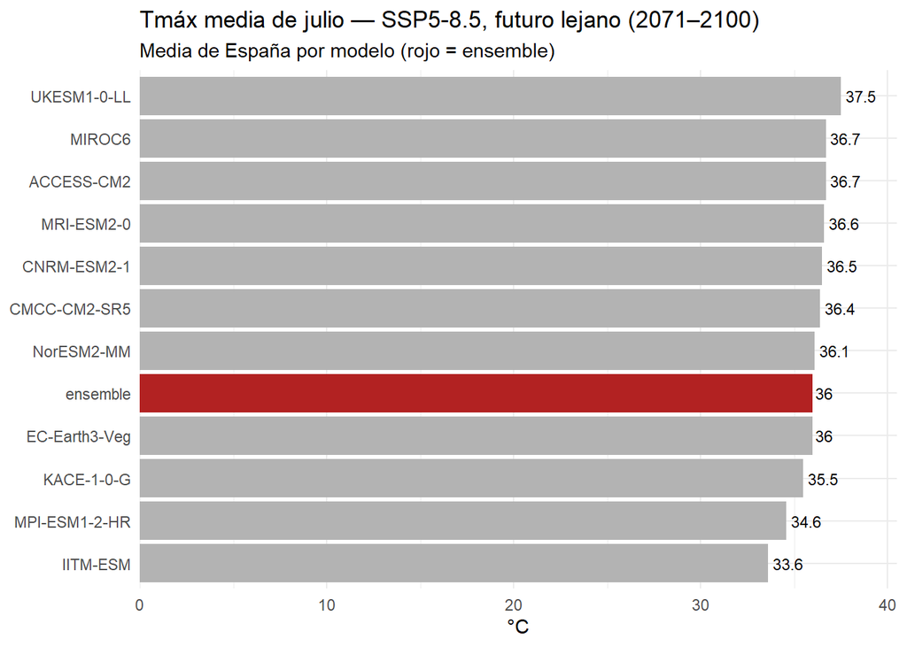

Series temporales por horizonte de cada modelo (tasmax, SSP5-8.5), promediadas a toda España: cada línea gris es un GCM y la roja el `ensemble`.

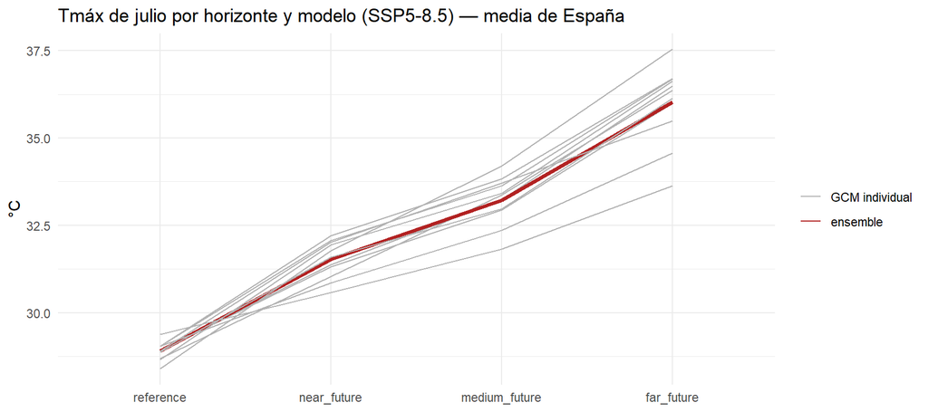

# 3 Incorporación del dataset a la memoria

Al compilar este documento se ha generado el fichero **`CLIMA_SPAIN_analisis.Rmd`**: es la sección *Análisis del dataset* de arriba, preparada para la sección **Comprensión de los datos** de la memoria, con los títulos al nivel de esa sección. Para incorporar el dataset a la memoria:

1. Copia a la carpeta de la memoria estos ficheros de la carpeta `CLIMA_SPAIN`: `observaciones_spain.rds`, `proyecciones_spain.rds`, `CLIMA_SPAIN_metadatos.xlsx` y `CLIMA_SPAIN_analisis.Rmd`.
2. Comprueba que en la carpeta de la memoria está también `utilidades.R` (viene en la carpeta `ProyectoPersonal`, junto al modelo de memoria) y que la memoria lo carga en el chunk de librerías: `source("utilidades.R")`.
3. Pega este chunk en la sección *Comprensión de los datos* de la memoria, cambiando los nombres de las tablas por otros que describan el dataset:

````
```{r, results='asis', cache=FALSE}
clima <- aedv_incluir_dataset("CLIMA_SPAIN_analisis.Rmd")
# este dataset tiene 2 tablas: aedv_incluir_dataset() las devuelve en una lista
clima_obs  <- clima$data  # observaciones mensuales por provincia
clima_proy <- clima$proy  # proyecciones por escenario, modelo y horizonte
```
````

Al compilar la memoria, el análisis aparece en el lugar del chunk y los datos quedan en las tablas `clima_obs` y `clima_proy` (tibbles), con las que se sigue trabajando en el resto de la memoria. Este dataset tiene 2 tablas: `aedv_incluir_dataset()` las devuelve juntas en una lista, y las líneas que siguen a la llamada las separan, cada una con su nombre. Si incorporas varios datasets, pega un chunk por cada uno, con nombres de tabla distintos. En un dataset auxiliar, que no tiene que cumplir los requisitos de AEDV, `aedv_incluir_dataset("CLIMA_SPAIN_analisis.Rmd", validacion = FALSE)` omite la validación.

El texto explicativo del dataset (qué mide, qué significa cada variable y cada una de sus opciones…) se escribe en la memoria, antes o después del chunk, no en `CLIMA_SPAIN_analisis.Rmd`: ese fichero se sustituye cada vez que se vuelve a generar.